# Análise Exploratória de Dados

Luiz Carlos Castro Cunha Junior

29/05/2021

[figure not shown]

## Estudo de Caso: Limite de Crédito

A base de dados traz informações dos clientes de um banco que solicitaram limite de crédito. Durante a análise deverá ser respondida às seguintes questões de negócio:

- Qual a idade média dos clientes presentes no banco de dados?
- Qual o valor do mínimo, máximo, mediana, Q1 e Q3 da variável idade?
- Existem clientes com idades discrepantes? Analise o boxplot.
- Existem clientes que possuem rendimento total discrepante em relação aos demais clientes? Analise o boxplot.
- A partir de qual valor o rendimento é considerado discrepante?
- A variável rendimento total pode ser considerada simétrica?
- Existem clientes que possuem salário discrepante em relação aos demais clientes?
- A partir de qual valor o salário é considerado discrepante?
- A variável salário pode ser considerada simétrica?
- Existem clientes que possuem limite de cheque especial discrepante em relação aos demais clientes? Analise o boxplot.
- A partir de qual valor o limite de cheque especial é considerado discrepante?
- A variável limite de cheque especial pode ser considerada simétrica?

### Carregando os pacotes a serem utilizados

```r
library(tidyverse)
library(readxl)
library(rstatix)
library(moments)
library(knitr)
library(rmarkdown)
library(kableExtra)
library(emmeans)
library(htmltools)
```

### Importando o Conjunto de Dados

```r
dataset<-readxl::read_xlsx("Exercícios.xlsx",
                  sheet = "Base de Dados 1")
colnames(dataset)[3]<-'RendimentoTotal'

knitr::kable(head(dataset,5))
```

| Código do Cliente | Idade | RendimentoTotal | Salário | Limite de Crédito Imediato | Limite do Cheque Especial |
| --- | --- | --- | --- | --- | --- |
| 12 | 72 | 4300 | 4300 | 2000 | 1000 |
| 44 | 75 | 4400 | 4400 | 3000 | 1000 |
| 30 | 66 | 4800 | 4800 | 440 | 1500 |
| 2 | 35 | 5000 | 5000 | 1000 | 1000 |
| 35 | 69 | 5000 | 5000 | 2000 | 2500 |

### Visualizando o tipo de dados das variáveis

```r
str(dataset)
```

```
## tibble [48 x 6] (S3: tbl_df/tbl/data.frame)
##  $ Código do Cliente         : num [1:48] 12 44 30 2 35 39 42 47 5 19 ...
##  $ Idade                     : num [1:48] 72 75 66 35 69 47 68 44 54 56 ...
##  $ RendimentoTotal           : num [1:48] 4300 4400 4800 5000 5000 5000 5000 5800 6000 6000 ...
##  $ Salário                   : num [1:48] 4300 4400 4800 5000 5000 5000 5000 5800 6000 6000 ...
##  $ Limite de Crédito Imediato: num [1:48] 2000 3000 440 1000 2000 2000 380 500 1790 2000 ...
##  $ Limite do Cheque Especial : num [1:48] 1000 1000 1500 1000 2500 1700 600 800 3600 2500 ...
```

### Perguntas de Negócio

> Qual a idade média dos clientes presentes no banco de dados?

A idade média dos clientes é 60.98

> Existem clientes com idades discrepantes?

Conforme podemos analisar no gráfico abaixo *não temos clientes comidades discrepantes* em relação aos outros clientes.

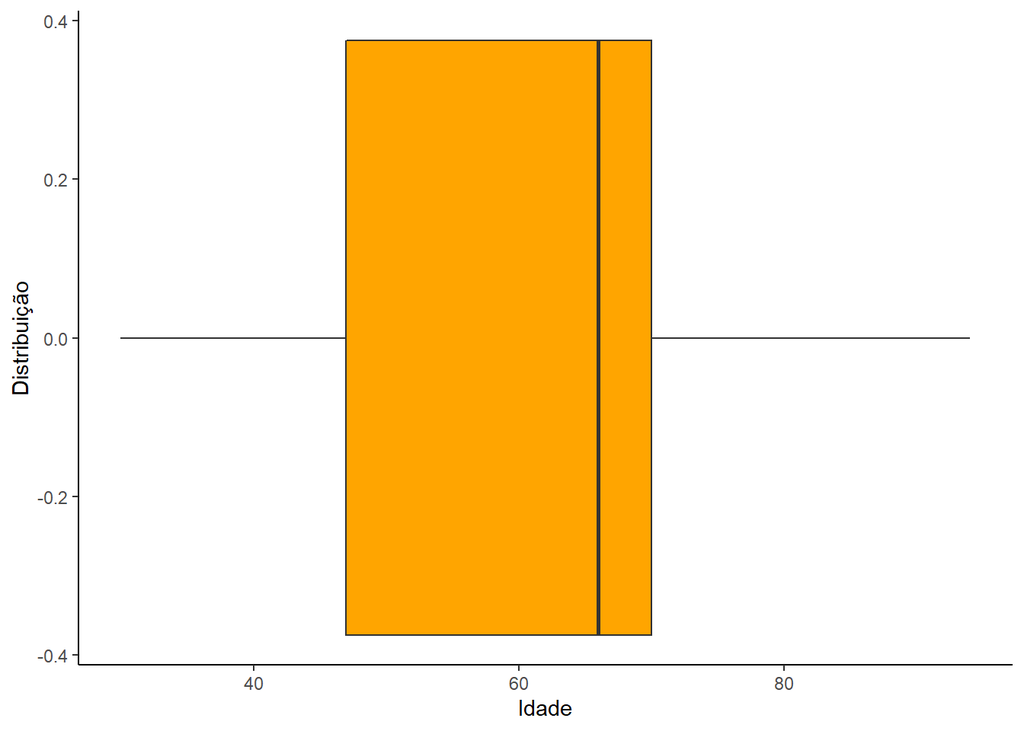

> Existem clientes que possuem rendimento total discrepante em relação aos demais clientes?

Podemos observar no gráfico abaixo que possuímos clientes cujo rendimento total é considerado discrepante em relação aos outros clientes.

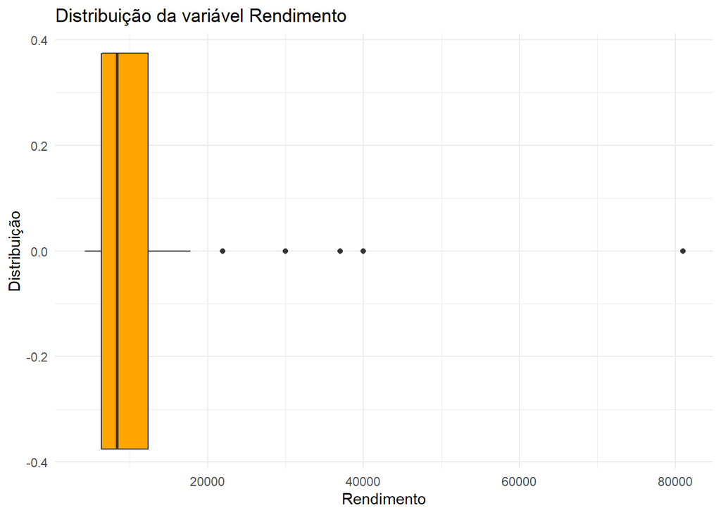

> A partir de qual valor o rendimento é considerado discrepante?

A partir do rendimento total de 21375

> A variável rendimento total pode ser considerada simétrica?

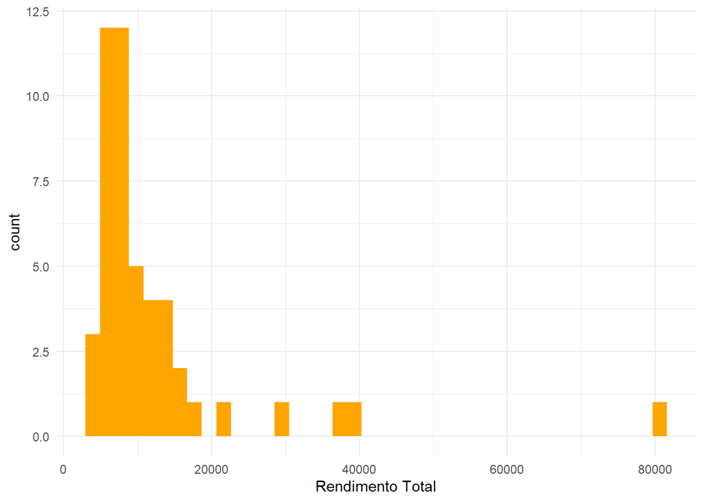

> Existem clientes que possuem salário discrepante em relação aos demais clientes?

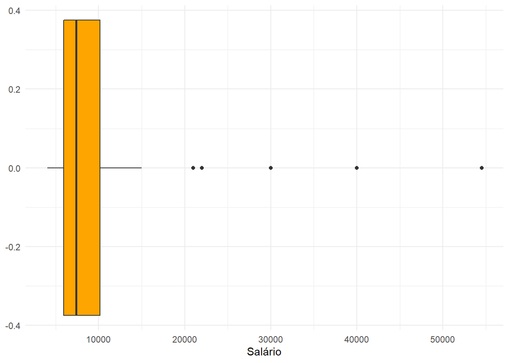

> A partir de qual valor o salário é considerado discrepante?

O salário pode ser considerado discrepante a partir de R$16482.5

> A variável salário pode ser considerada simétrica?

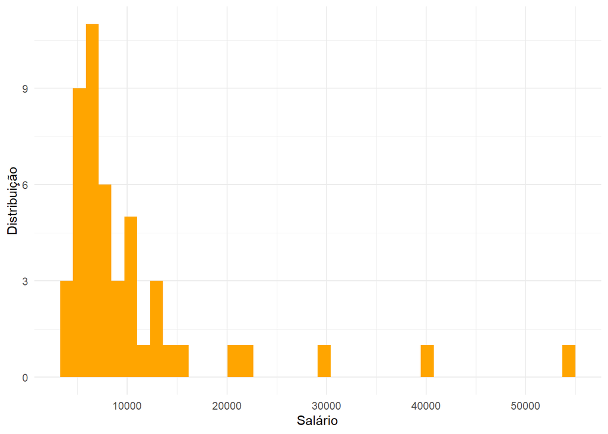

> Existem clientes que possuem limite de cheque especial discrepante em relação aos demais clientes?

Sim.

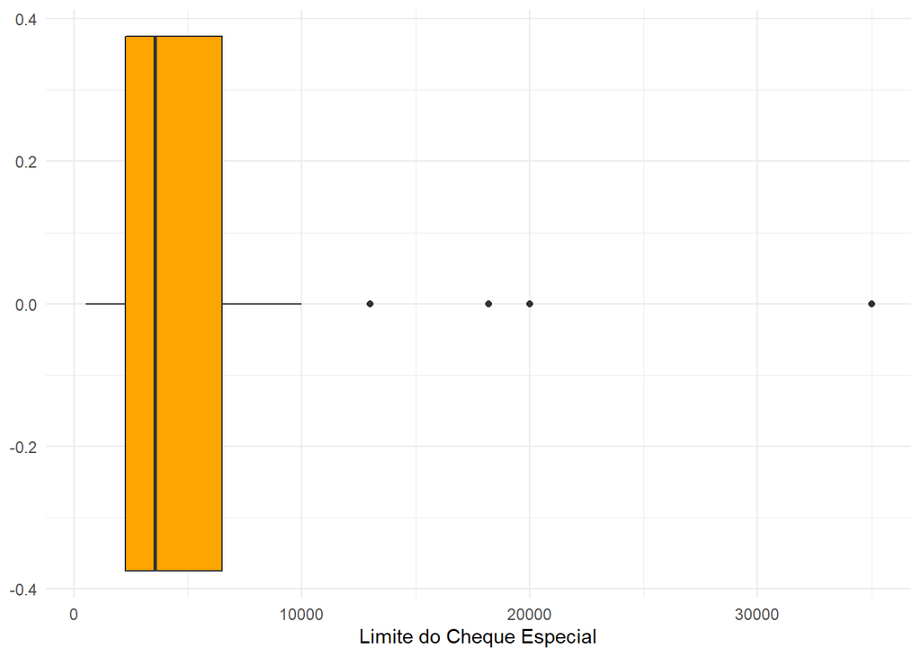

> A partir de qual valor o limite de cheque especial é considerado discrepante?

O valor do limite do cheque especial pode ser considerado discrepante a partir de R$ 12856.25

> A variável limite de cheque especial pode ser considerada simétrica?

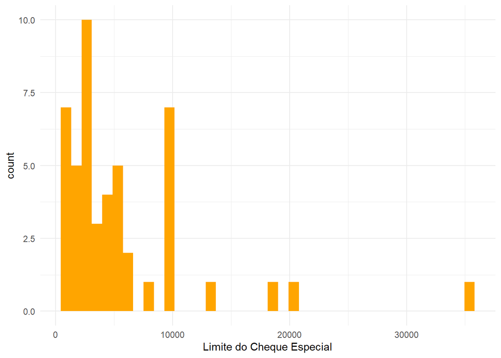